# R Notebook

### 内容

[こちらの記事](https://tensorflow.rstudio.com/blog/keras-customer-churn.html)を基にKerasを用いて離反予測を行う。また{lime}による結果の解釈を試みる。

1. 分析環境設定
2. データのロードと前処理
3. モデリングと精度評価
4. 結果の解釈

### 1. 分析環境設定

#### 必要なライブラリのインストール

```r
# pkgs <- c("keras", "lime", "tidyquant", "rsample", "recipes", "yardstick", "corrr")
# install.packages(pkgs)
```

#### ライブラリのロード

```r
library(keras)
library(lime)
library(tidyquant)
library(rsample)
library(recipes)
library(yardstick)
library(corrr)
library(haven)
```

#### Kerasのインストール

初めての場合、結構時間がかかる。以下のエラーが出た。そのまま対応。

> エラー: Prerequisites for installing TensorFlow not available. Execute the following at a terminal to install the prerequisites:

> $ sudo /usr/bin/easy_install pip

> $ sudo /usr/local/bin/pip install –upgrade virtualenv

```r
# install_keras()
```

以上で分析環境の設定は完了

### 2.データのロードと前処理

#### データの読み込み

IBM Watson Telco Datasetとして公開されているデータを使用する。

```r
churn_data_raw <- read_csv("/Users/nakahashi/Desktop/Git/R_Snippet/Data/WA_Fn-UseC_-Telco-Customer-Churn.csv")
glimpse(churn_data_raw)
```

```
Observations: 7,043
Variables: 21
$ customerID       <chr> "7590-VHVEG", "5575-GNVDE", "3668-QPYBK", "7795-...
$ gender           <chr> "Female", "Male", "Male", "Male", "Female", "Fem...
$ SeniorCitizen    <int> 0, 0, 0, 0, 0, 0, 0, 0, 0, 0, 0, 0, 0, 0, 0, 0, ...
$ Partner          <chr> "Yes", "No", "No", "No", "No", "No", "No", "No",...
$ Dependents       <chr> "No", "No", "No", "No", "No", "No", "Yes", "No",...
$ tenure           <int> 1, 34, 2, 45, 2, 8, 22, 10, 28, 62, 13, 16, 58, ...
$ PhoneService     <chr> "No", "Yes", "Yes", "No", "Yes", "Yes", "Yes", "...
$ MultipleLines    <chr> "No phone service", "No", "No", "No phone servic...
$ InternetService  <chr> "DSL", "DSL", "DSL", "DSL", "Fiber optic", "Fibe...
$ OnlineSecurity   <chr> "No", "Yes", "Yes", "Yes", "No", "No", "No", "Ye...
$ OnlineBackup     <chr> "Yes", "No", "Yes", "No", "No", "No", "Yes", "No...
$ DeviceProtection <chr> "No", "Yes", "No", "Yes", "No", "Yes", "No", "No...
$ TechSupport      <chr> "No", "No", "No", "Yes", "No", "No", "No", "No",...
$ StreamingTV      <chr> "No", "No", "No", "No", "No", "Yes", "Yes", "No"...
$ StreamingMovies  <chr> "No", "No", "No", "No", "No", "Yes", "No", "No",...
$ Contract         <chr> "Month-to-month", "One year", "Month-to-month", ...
$ PaperlessBilling <chr> "Yes", "No", "Yes", "No", "Yes", "Yes", "Yes", "...
$ PaymentMethod    <chr> "Electronic check", "Mailed check", "Mailed chec...
$ MonthlyCharges   <dbl> 29.85, 56.95, 53.85, 42.30, 70.70, 99.65, 89.10,...
$ TotalCharges     <dbl> 29.85, 1889.50, 108.15, 1840.75, 151.65, 820.50,...
$ Churn            <chr> "No", "No", "Yes", "No", "Yes", "Yes", "No", "No...
```

### 不要なデータの削除

顧客IDのようにユニークな列やNAを含む行を削除し、並び替え。

```r
churn_data_tbl <-
   churn_data_raw %>%
   select(-customerID) %>%
   drop_na() %>%
   select(Churn, everything())
glimpse(churn_data_tbl)
```

```
Observations: 7,032
Variables: 20
$ Churn            <chr> "No", "No", "Yes", "No", "Yes", "Yes", "No", "No...
$ gender           <chr> "Female", "Male", "Male", "Male", "Female", "Fem...
$ SeniorCitizen    <int> 0, 0, 0, 0, 0, 0, 0, 0, 0, 0, 0, 0, 0, 0, 0, 0, ...
$ Partner          <chr> "Yes", "No", "No", "No", "No", "No", "No", "No",...
$ Dependents       <chr> "No", "No", "No", "No", "No", "No", "Yes", "No",...
$ tenure           <int> 1, 34, 2, 45, 2, 8, 22, 10, 28, 62, 13, 16, 58, ...
$ PhoneService     <chr> "No", "Yes", "Yes", "No", "Yes", "Yes", "Yes", "...
$ MultipleLines    <chr> "No phone service", "No", "No", "No phone servic...
$ InternetService  <chr> "DSL", "DSL", "DSL", "DSL", "Fiber optic", "Fibe...
$ OnlineSecurity   <chr> "No", "Yes", "Yes", "Yes", "No", "No", "No", "Ye...
$ OnlineBackup     <chr> "Yes", "No", "Yes", "No", "No", "No", "Yes", "No...
$ DeviceProtection <chr> "No", "Yes", "No", "Yes", "No", "Yes", "No", "No...
$ TechSupport      <chr> "No", "No", "No", "Yes", "No", "No", "No", "No",...
$ StreamingTV      <chr> "No", "No", "No", "No", "No", "Yes", "Yes", "No"...
$ StreamingMovies  <chr> "No", "No", "No", "No", "No", "Yes", "No", "No",...
$ Contract         <chr> "Month-to-month", "One year", "Month-to-month", ...
$ PaperlessBilling <chr> "Yes", "No", "Yes", "No", "Yes", "Yes", "Yes", "...
$ PaymentMethod    <chr> "Electronic check", "Mailed check", "Mailed chec...
$ MonthlyCharges   <dbl> 29.85, 56.95, 53.85, 42.30, 70.70, 99.65, 89.10,...
$ TotalCharges     <dbl> 29.85, 1889.50, 108.15, 1840.75, 151.65, 820.50,...
```

### データを学習用と検証用に分割

{rsample}パッケージを用いることで、簡単に分割できる。

```r
set.seed(100)
train_test_split <- initial_split(churn_data_tbl, prop = 0.8)
train_test_split
```

```
<5626/1406/7032>
```

```r
# Retrieve train and test sets
train_tbl <- training(train_test_split)
test_tbl  <- testing(train_test_split)
```

### 変数変換

TotalChargesの対数変換が有効であるかを確認する。{corrr}パッケージの関数を使い体裁を整える。

```r
train_tbl %>%
   select(Churn, TotalCharges) %>%
   mutate(Churn = Churn %>% as.factor() %>% as.numeric(),
          LogTotalCharges = log(TotalCharges)) %>%
   correlate() %>%
   focus(Churn) %>%
   fashion()
```

| rowname | Churn |
| --- | --- |
| TotalCharges | -.20 |
| LogTotalCharges | -.25 |

### データ前処理レシピ作成

{recipe}パッケージでデータの前処理の手順を定義した**レシピ**を作成する。

```r
rec_obj <-
   recipe(Churn ~ ., data = train_tbl) %>% # 目的変数と説明変数の定義
   step_discretize(tenure, options = list(cuts = 6)) %>% # 連続変数のカテゴリ化
   step_log(TotalCharges) %>% # 対数変換
   step_dummy(all_nominal(), -all_outcomes()) %>% # カテゴリ変数のダミー化
   step_center(all_predictors(), -all_outcomes()) %>% # 説明変数の中心化
   step_scale(all_predictors(), -all_outcomes()) %>% # 説明変数のスケーリング
   prep(data = train_tbl) # レシピの完成
rec_obj
```

```
Data Recipe

Inputs:

      role #variables
   outcome          1
 predictor         19

Training data contained 5626 data points and no missing data.

Operations:

Dummy variables from tenure [trained]
Log transformation on TotalCharges [trained]
Dummy variables from gender, Partner, Dependents, tenure, ... [trained]
Centering for SeniorCitizen, MonthlyCharges, ... [trained]
Scaling for SeniorCitizen, MonthlyCharges, ... [trained]
```

### 前処理の実行

作成したレシピに基づき、データに前処理を施す。

```r
x_train_tbl <- bake(rec_obj, newdata = train_tbl) %>% select(-Churn)
x_test_tbl  <- bake(rec_obj, newdata = test_tbl) %>% select(-Churn)
glimpse(x_train_tbl)
```

```
Observations: 5,626
Variables: 35
$ SeniorCitizen                         <dbl> -0.4351959, -0.4351959, -0....
$ MonthlyCharges                        <dbl> -1.157597168, -0.260133339,...
$ TotalCharges                          <dbl> -2.275819130, 0.389259098, ...
$ gender_Male                           <dbl> -1.0016900, 0.9981354, 0.99...
$ Partner_Yes                           <dbl> 1.0262054, -0.9742906, -0.9...
$ Dependents_Yes                        <dbl> -0.6507747, -0.6507747, -0....
$ tenure_bin1                           <dbl> 2.1677790, -0.4612196, -0.4...
$ tenure_bin2                           <dbl> -0.4389453, -0.4389453, -0....
$ tenure_bin3                           <dbl> -0.4481273, -0.4481273, -0....
$ tenure_bin4                           <dbl> -0.4509837, 2.2169809, 2.21...
$ tenure_bin5                           <dbl> -0.4498419, -0.4498419, -0....
$ tenure_bin6                           <dbl> -0.4337508, -0.4337508, -0....
$ PhoneService_Yes                      <dbl> -3.0407367, 0.3288092, -3.0...
```

[output cut: 22 more lines]

### 目的変数

目的変数もダミー化しておく。

```r
y_train_vec <- ifelse(pull(train_tbl, Churn) == "Yes", 1, 0)
y_test_vec  <- ifelse(pull(test_tbl, Churn) == "Yes", 1, 0)
```

## 3.モデリングと精度評価

Kerasを用いてディープラーニングのモデルを定義する。

```r
model_keras <- keras_model_sequential()
model_keras %>%

   # 隠れ層の一つ目はユニット数を16とする。第一層なので入力は説明変数の数。
   layer_dense(
      units              = 16,
      kernel_initializer = "uniform",
      activation         = "relu",
      input_shape        = ncol(x_train_tbl)) %>%

   # 過学習を防ぐためのドロップアウト
   layer_dropout(rate = 0.1) %>%

   # 隠れ層の二つ目もユニット数を16とする
   layer_dense(
      units              = 16,
      kernel_initializer = "uniform",
      activation         = "relu") %>%

   # 過学習を防ぐためのドロップアウト
   layer_dropout(rate = 0.1) %>%

   # 出力層。活性化関数はsigmoid
   layer_dense(
      units              = 1,
      kernel_initializer = "uniform",
      activation         = "sigmoid") %>%

   # 勾配法：Adam、損失関数：クロスエントロピー、精度指標：accuracy
   compile(
      optimizer = 'adam',
      loss      = 'binary_crossentropy',
      metrics   = c('accuracy')
   )
model_keras
```

```
Model
______________________________________________________________________________
Layer (type)                       Output Shape                   Param #
==============================================================================
dense_1 (Dense)                    (None, 16)                     576
______________________________________________________________________________
dropout_1 (Dropout)                (None, 16)                     0
______________________________________________________________________________
dense_2 (Dense)                    (None, 16)                     272
______________________________________________________________________________
dropout_2 (Dropout)                (None, 16)                     0
______________________________________________________________________________
dense_3 (Dense)                    (None, 1)                      17
==============================================================================
Total params: 865
Trainable params: 865
Non-trainable params: 0
______________________________________________________________________________
```

### フィッティング

上記のモデルに従いフィッティングを行う。

```r
set.seed(123)
history <- fit(
   object           = model_keras,
   x                = as.matrix(x_train_tbl),
   y                = y_train_vec,
   batch_size       = 50,
   epochs           = 35,
   validation_split = 0.30
)
```

```
Train on 3938 samples, validate on 1688 samples
```

```
2018-01-15 23:55:06.746111: I tensorflow/core/platform/cpu_feature_guard.cc:137] Your CPU supports instructions that this TensorFlow binary was not compiled to use: SSE4.2 AVX AVX2 FMA
```

学習履歴の評価

```r
print(history)
```

```
Trained on 3,938 samples, validated on 1,688 samples (batch_size=50, epochs=35)
Final epoch (plot to see history):
     acc: 0.8126
    loss: 0.3979
 val_acc: 0.8027
val_loss: 0.4292
```

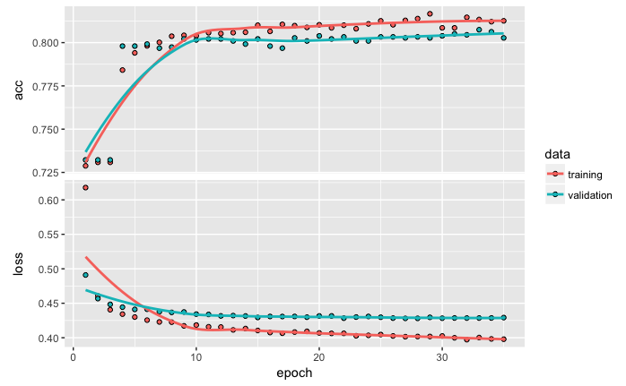

```r
plot(history)
```

### 精度評価

学習済みモデルによる予測を実施。

[output not shown]

[output cut: 990 more lines]

精度評価を実施。

```r
# 混同行列
estimates_keras_tbl %>% conf_mat(truth, estimate)
```

```
          Truth
Prediction  no yes
       no  941 150
       yes 108 207
```

```r
# 正解率
estimates_keras_tbl %>% metrics(truth, estimate)
```

| accuracy |
| --- |
| 0.8165007 |

```r
# AUC
estimates_keras_tbl %>% roc_auc(truth, class_prob)
```

```
[1] 0.8510106
```

```r
# Precision & Recall
tibble(
   precision = estimates_keras_tbl %>% precision(truth, estimate),
   recall    = estimates_keras_tbl %>% recall(truth, estimate)
)
```

| precision | recall |
| --- | --- |
| 0.6571429 | 0.5798319 |

```r
# F-Statistic
estimates_keras_tbl %>% f_meas(truth, estimate, beta = 1)
```

```
[1] 0.6160714
```

## 4.結果の解釈

以降は{lime}パッケージを用いた結果の解釈可能性について

```r
# Run explain() on explainer
explanation <- explain(
   x_test_tbl[1:10, ],
   explainer    = explainer,
   # labels       = 1,
   n_labels     = 1,
   n_features   = 4,
   kernel_width = 0.5
)
```

[output not shown]

```r
corrr_analysis <-
   x_train_tbl %>%
   mutate(Churn = y_train_vec) %>%
   correlate() %>%
   focus(Churn) %>%
   rename(feature = rowname) %>%
   arrange(abs(Churn)) %>%
   mutate(feature = as_factor(feature))
corrr_analysis
```

| feature | Churn |
| --- | --- |
| gender_Male | -0.006690899 |
| tenure_bin3 | -0.009557165 |
| MultipleLines_No.phone.service | -0.016950072 |
| PhoneService_Yes | 0.016950072 |
| MultipleLines_Yes | 0.032103354 |
| StreamingTV_Yes | 0.066192594 |
| StreamingMovies_Yes | 0.067643871 |
| DeviceProtection_Yes | -0.073301197 |
| tenure_bin4 | -0.073371838 |
| PaymentMethod_Mailed.check | -0.080451164 |

[output cut: 25 more lines]

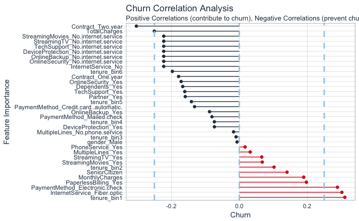

```r
ggplot(data = corrr_analysis,
       aes(x = Churn, y = fct_reorder(feature, desc(Churn)))) +
   geom_point() +
   # Positive Correlations - Contribute to churn
   geom_segment(aes(xend = 0, yend = feature),
                color = palette_light()[[2]],
                data = corrr_analysis %>% filter(Churn > 0)) +
   geom_point(color = palette_light()[[2]],
              data = corrr_analysis %>% filter(Churn > 0)) +
   # Negative Correlations - Prevent churn
   geom_segment(aes(xend = 0, yend = feature),
                color = palette_light()[[1]],
                data = corrr_analysis %>% filter(Churn < 0)) +
   geom_point(color = palette_light()[[1]],
              data = corrr_analysis %>% filter(Churn < 0)) +
   # Vertical lines
   geom_vline(xintercept = 0, color = palette_light()[[5]], size = 1, linetype = 2) +
   geom_vline(xintercept = -0.25, color = palette_light()[[5]], size = 1, linetype = 2) +
   geom_vline(xintercept = 0.25, color = palette_light()[[5]], size = 1, linetype = 2) +
   # Aesthetics
   theme_tq() +
   labs(title = "Churn Correlation Analysis",
        subtitle = "Positive Correlations (contribute to churn), Negative Correlations (prevent churn)",
        y = "Feature Importance")
```